# Methods for Toddler’s Comprehension of Negation (Pilot Study)

Jasbi, McDermott-Hinman, Feiman, Davidson, Snedeker, Carey

6/30/2019

This pilot study addresses the following main question: At what age do toddlers understand negation in the context of rejection? We plan to extend this paradigm to test negation in the context of denial and non-existence in the future.

## Design Summary

The study presents toddlers with videos and measures their looking time to the screen in a violation of expectation paradigm (Baillargeon, Spelke, and Wasserman 1985). In each trial, there are two puppets and two objects on the screen. One puppet asks the other if they want one of the objects. The second puppet answers with “yes” or “no”. Then the first puppet gives either the desired object, or the object that was rejected. We hypothesize that knowledge of negation in the context of rejecting desires results in surprise when the puppet provides a rejected object.

The study has four within-subject trial types. These four trial-types are created based on two factors:

1. Negation: Whether the answer to the question is positive (yes) or negative (no)
2. Consistency: Whether the desired or the rejected object is given

The table below summarizes the study’s $2\times2$ design. Positive trial types consititue the control condition and negative trial types constitute the test condition.

| Trial-Type | Objects | Question | Answer | Object Received |
| --- | --- | --- | --- | --- |
| Positive-Consistent | X, Y | Do you want the X? | Yes | X |
| Positive-Inconsistent | X, Y | Do you want the X? | Yes | Y |
| Negative-Consistent | X, Y | Do you want the X? | No | Y |
| Negative-Inconsistent | X, Y | Do you want the X? | No | X |

## Stimuli

### Puppets

The study had two puppets: Yuni the unicorn and Diego the Dragon. Yuni is the puppet that receives objects and Diego is the puppet that asks Yuni what she wants and gives her an object.

### Objects

We used four pairs of objects (one per trial type):

1. an apple and a banana,
2. small ball and a toy car
3. rubber duck and a teddy bear
4. a cup and a spoon.

### Words

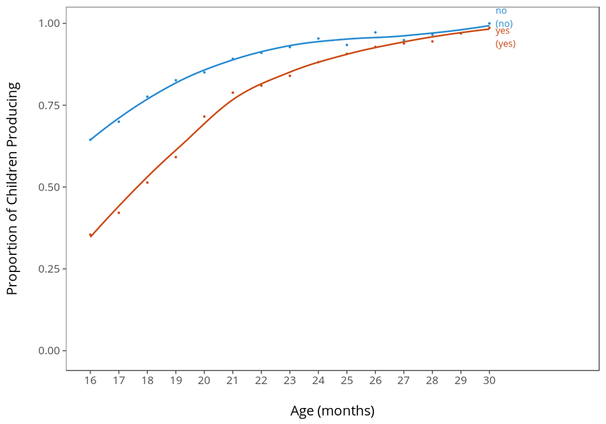

According to CDI data, around 27 months of age almost all children produce “yes” and “no”. The names for all of the objects used are produced by more than 75% of children at 27 months, and are among the first nouns that children produce, as reported by parents (wordbank.stanford.edu). Additionally, Bergelson and Swingley (2012) and Bergelson and Swingley (2015) provide good evidence that children understand common nouns long before they begin to produce them (as early as 6-9 months).

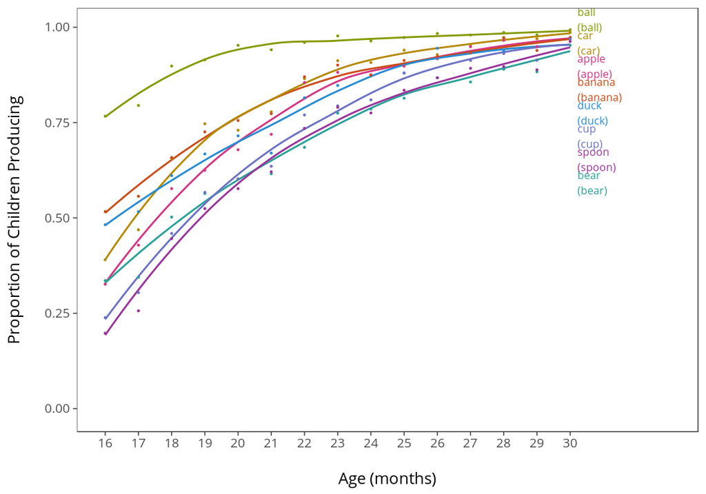

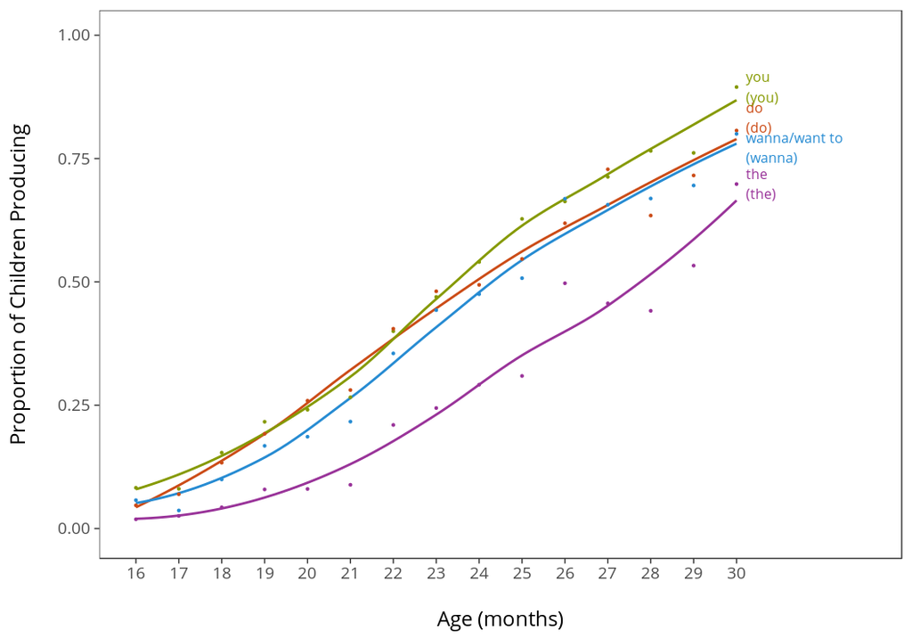

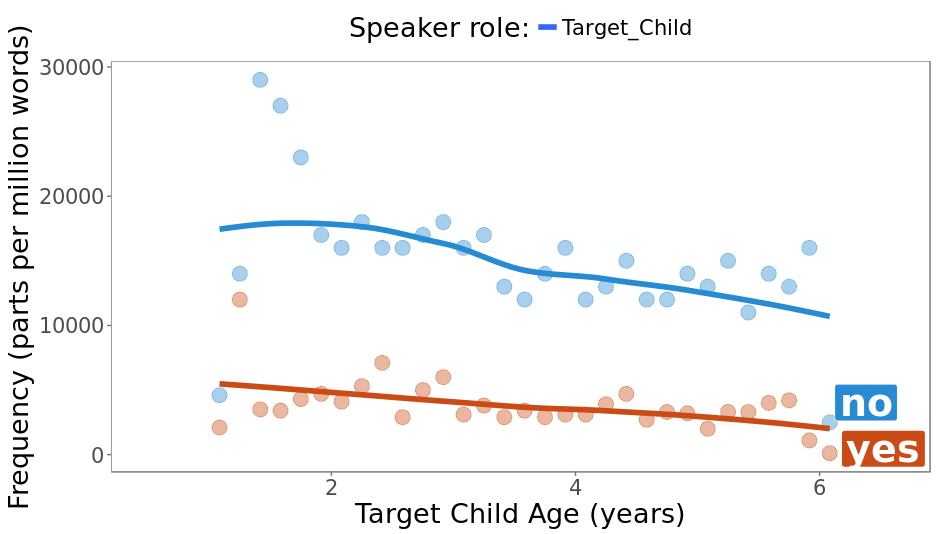

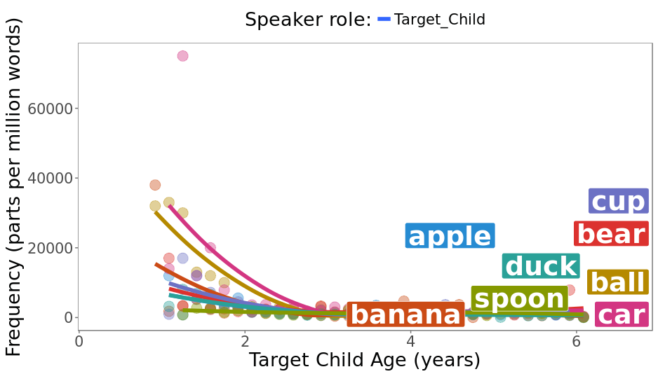

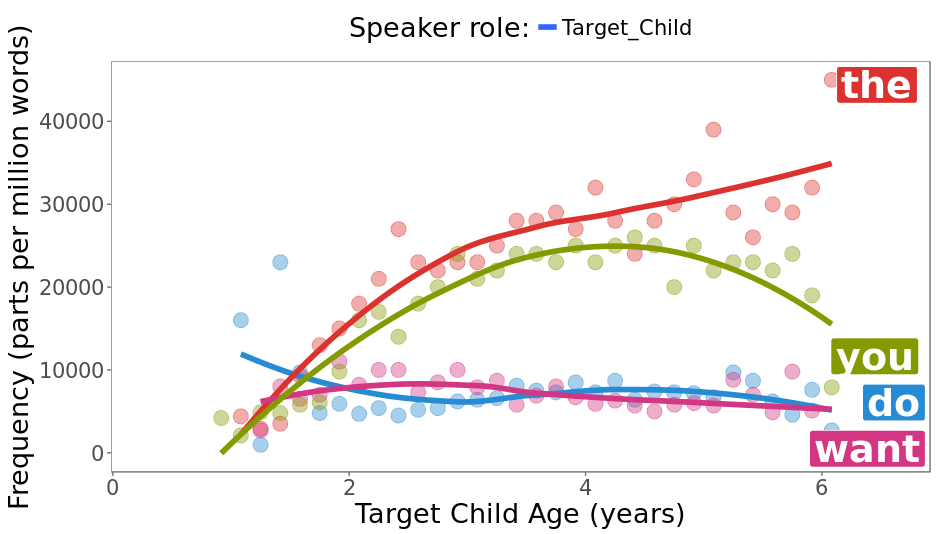

### Video and Audio Recording/Editing

Audio stimuli were recorded separately in a phonetics lab’s recording studio and added to the videos. The first author acted as the voice of Diego and the second author as the voice of Yuni. For Diego the recordings included: “Hi Yuni”, “Alright”, and 8 utterances of “Do you want the X?” where X was the lable of one of the objects. For Yuni, the recordings included “yes” and “no”. Each video had a positive version in which “yes” was edited over on Yuni’s mouth movements and a negative version that had “no” insetead. It also had a two versions for which object Diego asked for. In total, there were 64 test trial videos and 5 introduction videos used in the experiment. All video and audio stimuili are available for inspection in the stimuli folder of this study’s repository.

## Procedure

The study started with the puppets entering the scene and introducing themselves. After this introduction video children saw 12 videos in 4 blocks. Each block had 3 trials: one introduction video to the objects followed by two test trials.

### Design

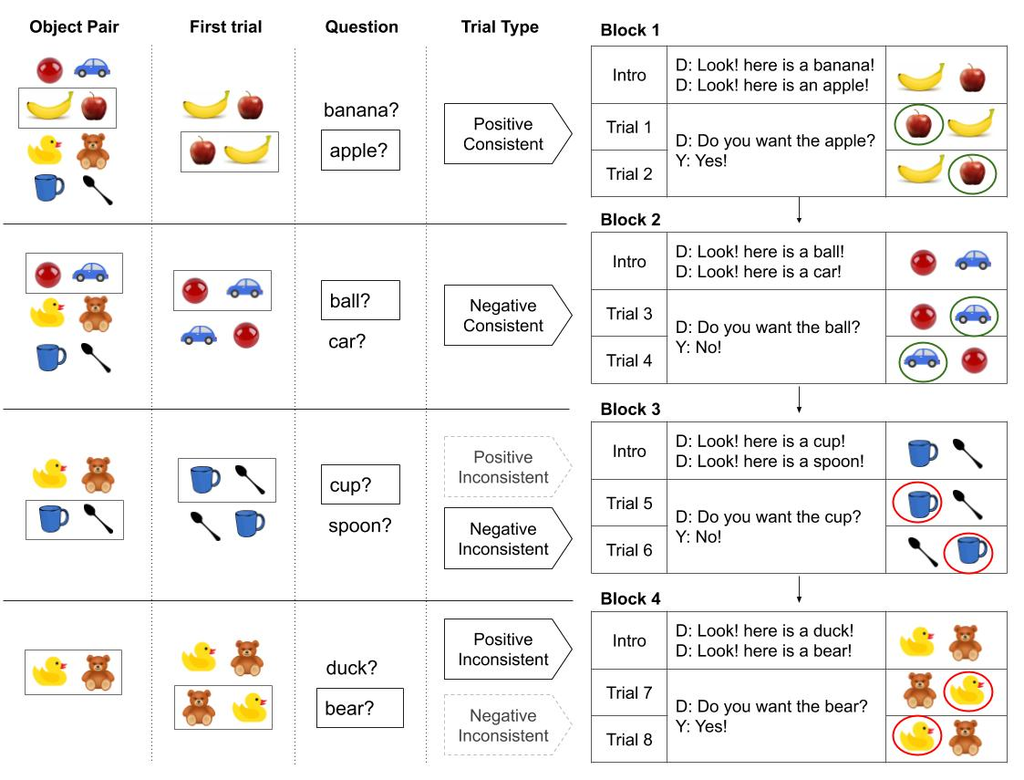

Study design, randomization, and example trials.

The figure above shows the study design, randomization, and procedure. From left to right, it shows the elements that were randomized, the experiental blocks, and example trials within blocks. For each participant, object pairs were assigned randomly to the four blocks and counterbalanced across participants. In the figure above, the pair apple-banana is assigned to the first block, ball-car to the second, cup-spoon to the third, and duck-bear to the fourth. Within each block, children first saw a video introducing and labeling the objects. Then they saw two trials which only differed with respect to the position of the objects on the screen. For each block, it was randomly decided which object label is going to be used to form the question “Do you want X?”.

The first experimental block was always the positive-consistent block in which Diego asked if Yuni wants an object, Yuni said “yes”, and Diego gave Yuni the object. The second block was always the negative-consistent block: Diego asked if Yuni wants an object, Yuni said “no”, so Diego gave Yuni the other object. Previous research has shown that in experimental settings, comprehension is better scaffolded in toddlers if negative trials follow positive ones and not vice versa. After the second block, participants randomly saw one of the positive or negative inconsistent blocks, followed by the other. The inconsistent blocks were randomized to reduce possible systmatic decrease of looking times in the fourth block due to famliarity with Diego’s inconsistent behavior.

## Participants

Csibra et al. (2016) report that the average effect size in infant looking time studies is about 0.6. Based on this they recommend at least 12 participants and for smaller than usual effect sizes at least 26 participants. Therefore, for our pilot study we aimed at recruiting between 12-26 participants in the age range of 24-30 months. All participants were monolingual; they were only exposed to English.

## Measurment

Our dependent measure was the duration of infant’s looking at the screen after a trial video had ended. All trials ended with the last frame frozen on the screen. We moved to the next trial if infants stopped looking at the screen for more than 2 seconds. Timing, trial ordering, and presentation were managed using the open source software [PyHab developed by Jonathan Kominsky](https://github.com/jfkominsky/PyHab/releases).

The stimuli were controlled by the experimenter, unaware of the stimuli but with a live feed of the child. The experimenter coded the child’s looking time by pressing a key when the child was looking at the screen and releasing when the child looked away. Each trial ended when the last frame was showing and the experimenter had indicated that the child had been looking away from the screen for 2 seconds.

## Results and Analyses

Assuming that toddlers understood the basics of our task, as well as the meaning of the words used including “yes” and “no”, we predicted that:

1. Toddlers will look longer at inconsistent trials than consistent ones.
2. Toddlers will look longer at negative inconsistent trials than positive ones.

To verify these predictions we use a Bayesian mixed effects linear regression with the fixed effects of consistency (consistent/inconsistent) and negation (yes/no). These factors will be dummy coded with the intercept of the model as positive consistent trials. Following Barr et al. (2013), we use the maximal by subject and item random effects allowed by our design. Following Csibra et al. (2016), we log-transform the infant looking time for our statistical analyses.

$log(lookingTime_{ij}) \sim \alpha + \beta_{inconsistency} \times consistency + \beta_{negative} \times negation + \beta_{incons.neg}\times negation \times consistency$

Prediction: main effect of consistency, no main effect of answer, significant interaction between consistency and answer: longer looking time in inconsistent negative trials.

## Alternative Accounts

- label-object matching account: if the object given is the label mentioned then no surprise, but if it’s a different one = surprise. Predicts surprise at match trials 1 and 4.
- Response matching: if the puppet says no, then there is a surprise. Not if it says yes. Predicts surprise at negative blocks.

## Discussion

Based on the pilot study, we plan to make changes to our materials and design to improve it for the final version of the study. The changes will be reflected in the final study’s methods description and will be pre-registered before data collection.

## References

Baillargeon, Renee, Elizabeth S Spelke, and Stanley Wasserman. 1985. “Object Permanence in Five-Month-Old Infants.” *Cognition* 20 (3). Elsevier: 191–208.

Barr, Dale J, Roger Levy, Christoph Scheepers, and Harry J Tily. 2013. “Random Effects Structure for Confirmatory Hypothesis Testing: Keep It Maximal.” *Journal of Memory and Language* 68 (3). Elsevier: 255–78.

Bergelson, Elika, and Daniel Swingley. 2012. “At 6–9 Months, Human Infants Know the Meanings of Many Common Nouns.” *Proceedings of the National Academy of Sciences* 109 (9). National Acad Sciences: 3253–8.

———. 2015. “Early Word Comprehension in Infants: Replication and Extension.” *Language Learning and Development* 11 (4). Taylor & Francis: 369–80.

Csibra, Gergely, Mikołaj Hernik, Olivier Mascaro, Denis Tatone, and Máté Lengyel. 2016. “Statistical Treatment of Looking-Time Data.” *Developmental Psychology* 52 (4). American Psychological Association: 521.